# ECommerce Transaction Data Analysis

Matthew A Smith

2025-10-05

## Introduction

I will be analyzing a transaction data set which contains all the transactions occurring between 01/12/2010 and 09/12/2011 for a UK-based and registered non-store online retail. The company mainly sells unique all-occasion gifts. Many customers of the company are wholesalers.

### Dataset Source

Chen, D. (2015). Online Retail [Dataset]. UCI Machine Learning Repository. https://doi.org/10.24432/C5BW33.

### Metadata

- InvoiceNo: Invoice number.
  - Nominal, a 6-digit integral number uniquely assigned to each transaction. If this code starts with letter ‘c’, it indicates a cancellation.
- StockCode: Product (item) code.
  - Nominal, a 5-digit integral number uniquely assigned to each distinct product.
- Description: Product (item) name.
  - Nominal.
- Quantity: The quantities of each product (item) per transaction.
  - Numeric.
- InvoiceDate: Invoice Date and time.
  - Numeric, the day and time when each transaction was generated.
- UnitPrice: Unit price.
  - Numeric, Product price per unit in sterling.
- CustomerID: Customer number.
  - Nominal, a 5-digit integral number uniquely assigned to each customer.
- Country: Country name.
  - Nominal, the name of the country where each customer resides.

## Setting up the environment

```r
if(!require(readxl)) install.packages('readxl')
if(!require(car)) install.packages('car')
if(!require(psych)) install.packages('psych')
```

```r
suppressPackageStartupMessages(library(tidyverse))
suppressPackageStartupMessages(library(readr))
suppressPackageStartupMessages(library(ggplot2))
suppressPackageStartupMessages(library(janitor))
suppressPackageStartupMessages(library(car))
suppressPackageStartupMessages(library(readxl))
suppressPackageStartupMessages(library(dplyr))
suppressPackageStartupMessages(library(psych))
suppressPackageStartupMessages(library(lubridate))
suppressPackageStartupMessages(library(bslib))
```

### Import the dataset

```r
retail_raw <- read_excel("Online Retail.xlsx", sheet = 1)
```

## Data exploration

```r
head(retail_raw)
```

```
## # A tibble: 6 × 8
##   InvoiceNo StockCode Description         Quantity InvoiceDate         UnitPrice
##   <chr>     <chr>     <chr>                  <dbl> <dttm>                  <dbl>
## 1 536365    85123A    WHITE HANGING HEAR…        6 2010-12-01 08:26:00      2.55
## 2 536365    71053     WHITE METAL LANTERN        6 2010-12-01 08:26:00      3.39
## 3 536365    84406B    CREAM CUPID HEARTS…        8 2010-12-01 08:26:00      2.75
## 4 536365    84029G    KNITTED UNION FLAG…        6 2010-12-01 08:26:00      3.39
## 5 536365    84029E    RED WOOLLY HOTTIE …        6 2010-12-01 08:26:00      3.39
## 6 536365    22752     SET 7 BABUSHKA NES…        2 2010-12-01 08:26:00      7.65
## # ℹ 2 more variables: CustomerID <dbl>, Country <chr>
```

```r
summary(retail_raw)
```

```
##   InvoiceNo          StockCode         Description           Quantity
##  Length:541909      Length:541909      Length:541909      Min.   :-80995.000
##  Class :character   Class :character   Class :character   1st Qu.:     1.000
##  Mode  :character   Mode  :character   Mode  :character   Median :     3.000
##                                                           Mean   :     9.552
##                                                           3rd Qu.:    10.000
##                                                           Max.   : 80995.000
##
##   InvoiceDate                    UnitPrice            CustomerID
##  Min.   :2010-12-01 08:26:00   Min.   :-11062.060   Min.   :12346
##  1st Qu.:2011-03-28 11:34:00   1st Qu.:     1.250   1st Qu.:13953
##  Median :2011-07-19 17:17:00   Median :     2.080   Median :15152
##  Mean   :2011-07-04 13:34:57   Mean   :     4.611   Mean   :15288
##  3rd Qu.:2011-10-19 11:27:00   3rd Qu.:     4.130   3rd Qu.:16791
##  Max.   :2011-12-09 12:50:00   Max.   : 38970.000   Max.   :18287
##                                                     NA's   :135080
##    Country
##  Length:541909
##  Class :character
##  Mode  :character
##
##
##
##
```

## Cleaning: Issues

1. The InvoiceDate column contains both the data in time in a YYYY-MM-DD 00:00:00 format. Separate columns will allow for deeper analysis.

### Cleaning: Process

Load the data into a dataframe, naming it “df”, then separate the columns.

```r
df <- retail_raw

# Step One: Convert the InvoiceDate column to a datetime format
df$InvoiceDate <- ymd_hms(df$InvoiceDate)

# Step Two: Mutate() to create new columns for date and time
df_clean <- df %>%
  mutate(
    date_only = as.Date(InvoiceDate),
    time_only = format(InvoiceDate, "%H:%M:%S")
  )

# Check the updated data frame
head(df_clean)
```

```
## # A tibble: 6 × 10
##   InvoiceNo StockCode Description         Quantity InvoiceDate         UnitPrice
##   <chr>     <chr>     <chr>                  <dbl> <dttm>                  <dbl>
## 1 536365    85123A    WHITE HANGING HEAR…        6 2010-12-01 08:26:00      2.55
## 2 536365    71053     WHITE METAL LANTERN        6 2010-12-01 08:26:00      3.39
## 3 536365    84406B    CREAM CUPID HEARTS…        8 2010-12-01 08:26:00      2.75
## 4 536365    84029G    KNITTED UNION FLAG…        6 2010-12-01 08:26:00      3.39
## 5 536365    84029E    RED WOOLLY HOTTIE …        6 2010-12-01 08:26:00      3.39
## 6 536365    22752     SET 7 BABUSHKA NES…        2 2010-12-01 08:26:00      7.65
## # ℹ 4 more variables: CustomerID <dbl>, Country <chr>, date_only <date>,
## #   time_only <chr>
```

## Transformation: Additions

1. Returns are represented by a negative quantity. A new column could help identify returns.
2. As is, the data set does not allow for easy analysis of international versus domestic orders. Creating a new column identifying orders as Domestic or International may be helpful.
3. Add a revenue column to df_clean3.

### Transformation: Process

1. Utilize dplyr package to add a new column and if_else() statements to create a Return or Order designation.

```r
# Create the new 'transaction_type' column
df_clean2 <- df_clean %>%
  mutate(transaction_type = if_else(Quantity < 0, "Return", "Order"))

# Check the new dataframe
head(df_clean2)
```

```
## # A tibble: 6 × 11
##   InvoiceNo StockCode Description         Quantity InvoiceDate         UnitPrice
##   <chr>     <chr>     <chr>                  <dbl> <dttm>                  <dbl>
## 1 536365    85123A    WHITE HANGING HEAR…        6 2010-12-01 08:26:00      2.55
## 2 536365    71053     WHITE METAL LANTERN        6 2010-12-01 08:26:00      3.39
## 3 536365    84406B    CREAM CUPID HEARTS…        8 2010-12-01 08:26:00      2.75
## 4 536365    84029G    KNITTED UNION FLAG…        6 2010-12-01 08:26:00      3.39
## 5 536365    84029E    RED WOOLLY HOTTIE …        6 2010-12-01 08:26:00      3.39
## 6 536365    22752     SET 7 BABUSHKA NES…        2 2010-12-01 08:26:00      7.65
## # ℹ 5 more variables: CustomerID <dbl>, Country <chr>, date_only <date>,
## #   time_only <chr>, transaction_type <chr>
```

2. Next, create a column using similar functions to identify domestic versus international orders.

```r
# Create the new 'shipping_type' column
df_clean3 <- df_clean2 %>%
  mutate(shipping_type = if_else(Country == "United Kingdom", "Domestic", "International"))

# Check the new dataframe
head(df_clean3)
```

```
## # A tibble: 6 × 12
##   InvoiceNo StockCode Description         Quantity InvoiceDate         UnitPrice
##   <chr>     <chr>     <chr>                  <dbl> <dttm>                  <dbl>
## 1 536365    85123A    WHITE HANGING HEAR…        6 2010-12-01 08:26:00      2.55
## 2 536365    71053     WHITE METAL LANTERN        6 2010-12-01 08:26:00      3.39
## 3 536365    84406B    CREAM CUPID HEARTS…        8 2010-12-01 08:26:00      2.75
## 4 536365    84029G    KNITTED UNION FLAG…        6 2010-12-01 08:26:00      3.39
## 5 536365    84029E    RED WOOLLY HOTTIE …        6 2010-12-01 08:26:00      3.39
## 6 536365    22752     SET 7 BABUSHKA NES…        2 2010-12-01 08:26:00      7.65
## # ℹ 6 more variables: CustomerID <dbl>, Country <chr>, date_only <date>,
## #   time_only <chr>, transaction_type <chr>, shipping_type <chr>
```

3. Add a revenue column to the newest dataframe:

```r
# Using mutate() to create a new column called Revenue
# by multiplying Quantity by UnitPrice, returns (which have negative Quantity)
# will automatically result in negative Revenue.
df_clean3_with_revenue <- df_clean3 %>%
  mutate(Revenue = Quantity * UnitPrice)

print("--- Data Frame after adding Revenue column (First 5 rows): ---")
```

```
## [1] "--- Data Frame after adding Revenue column (First 5 rows): ---"
```

```r
print(head(df_clean3_with_revenue, 5))
```

```
## # A tibble: 5 × 13
##   InvoiceNo StockCode Description         Quantity InvoiceDate         UnitPrice
##   <chr>     <chr>     <chr>                  <dbl> <dttm>                  <dbl>
## 1 536365    85123A    WHITE HANGING HEAR…        6 2010-12-01 08:26:00      2.55
## 2 536365    71053     WHITE METAL LANTERN        6 2010-12-01 08:26:00      3.39
## 3 536365    84406B    CREAM CUPID HEARTS…        8 2010-12-01 08:26:00      2.75
## 4 536365    84029G    KNITTED UNION FLAG…        6 2010-12-01 08:26:00      3.39
## 5 536365    84029E    RED WOOLLY HOTTIE …        6 2010-12-01 08:26:00      3.39
## # ℹ 7 more variables: CustomerID <dbl>, Country <chr>, date_only <date>,
## #   time_only <chr>, transaction_type <chr>, shipping_type <chr>, Revenue <dbl>
```

## Analysis: Stakeholder Requests

Below is a series of requests stakeholders may ask of this e-commerce dataset. These questions may help the company better understand of business performance, identify trends, and spot potential issues.

1. What is the total sales revenue?
2. Which products have been returned the most?
3. How do domestic and international sales compare?
4. What are the most returned products?
5. What is the return rate, for odmestic and international orders?
6. Which countries generate the most sales?
7. How does sales revenue trend over time (e.g., by month)?
8. What is the average order value (AOV)?

## Analysis: Process

#### 1. What is the total sales revenue?

```r
# Step One: Create a revenue column
df_clean3 <- df_clean2 %>%
  mutate(Revenue = Quantity * UnitPrice)

# Check the new dataframe
head(df_clean3)
```

```
## # A tibble: 6 × 12
##   InvoiceNo StockCode Description         Quantity InvoiceDate         UnitPrice
##   <chr>     <chr>     <chr>                  <dbl> <dttm>                  <dbl>
## 1 536365    85123A    WHITE HANGING HEAR…        6 2010-12-01 08:26:00      2.55
## 2 536365    71053     WHITE METAL LANTERN        6 2010-12-01 08:26:00      3.39
## 3 536365    84406B    CREAM CUPID HEARTS…        8 2010-12-01 08:26:00      2.75
## 4 536365    84029G    KNITTED UNION FLAG…        6 2010-12-01 08:26:00      3.39
## 5 536365    84029E    RED WOOLLY HOTTIE …        6 2010-12-01 08:26:00      3.39
## 6 536365    22752     SET 7 BABUSHKA NES…        2 2010-12-01 08:26:00      7.65
## # ℹ 6 more variables: CustomerID <dbl>, Country <chr>, date_only <date>,
## #   time_only <chr>, transaction_type <chr>, Revenue <dbl>
```

```r
view(df_clean3$Revenue)

# Step Two: Calculate total sales revenue
sum(df_clean3$Revenue)
```

```
## [1] 9747748
```

```r
# Step Three: Name the total revenue as an object in the data frame
total_revenue <- df_clean3 %>%
  summarise(TotalRevenue = round(sum(Revenue), 2))
print("Total Sales Revenue:")
```

```
## [1] "Total Sales Revenue:"
```

```r
print(total_revenue)
```

```
## # A tibble: 1 × 1
##   TotalRevenue
##          <dbl>
## 1     9747748.
```

The total sales revenue for all transactions occurring between 01/12/2010 and 09/12/2011 is **£9,747,748.00**.

#### 2. Which products have been returned the most?

```r
# Step One: Filter the dataset to include only returns (Quantity is negative)
returns_df <- df_clean3 %>%
  filter(Quantity < 0)

print("Data frame filtered to show only returns:")
```

```
## [1] "Data frame filtered to show only returns:"
```

```r
print(head(returns_df))
```

```
## # A tibble: 6 × 12
##   InvoiceNo StockCode Description         Quantity InvoiceDate         UnitPrice
##   <chr>     <chr>     <chr>                  <dbl> <dttm>                  <dbl>
## 1 C536379   D         Discount                  -1 2010-12-01 09:41:00     27.5
## 2 C536383   35004C    SET OF 3 COLOURED …       -1 2010-12-01 09:49:00      4.65
## 3 C536391   22556     PLASTERS IN TIN CI…      -12 2010-12-01 10:24:00      1.65
## 4 C536391   21984     PACK OF 12 PINK PA…      -24 2010-12-01 10:24:00      0.29
## 5 C536391   21983     PACK OF 12 BLUE PA…      -24 2010-12-01 10:24:00      0.29
## 6 C536391   21980     PACK OF 12 RED RET…      -24 2010-12-01 10:24:00      0.29
## # ℹ 6 more variables: CustomerID <dbl>, Country <chr>, date_only <date>,
## #   time_only <chr>, transaction_type <chr>, Revenue <dbl>
```

```r
# Step Two: Calculate the total number of items returned for each product
most_returned_products <- returns_df %>%
  group_by(Description) %>%  # use a product identifier like 'StockCode' or 'Description'
  summarise(TotalReturned = sum(abs(Quantity))) %>%
  arrange(desc(TotalReturned))

print("Top 10 most returned products:")
```

```
## [1] "Top 10 most returned products:"
```

```r
print(head(most_returned_products, 10)) # 10 can be changed to any amount
```

```
## # A tibble: 10 × 2
##    Description                         TotalReturned
##    <chr>                                       <dbl>
##  1 PAPER CRAFT , LITTLE BIRDIE                 80995
##  2 MEDIUM CERAMIC TOP STORAGE JAR              74494
##  3 <NA>                                        46156
##  4 printing smudges/thrown away                19200
##  5 Unsaleable, destroyed.                      15644
##  6 check                                       13247
##  7 ?                                            9496
##  8 ROTATING SILVER ANGELS T-LIGHT HLDR          9376
##  9 Printing smudges/thrown away                 9058
## 10 Damaged                                      7540
```

Above is a list of the top 10 most commonly returned items. For example, the **“Little Birdie Paper Craft”** was the most frequently returned product with 80,995 returns. In second place is the **“Medium Ceramic Top Storage Jar”** with 74,494 returns.

As you can see, the third most commonly returned item is marked with an “NA”. The seventh item is listed as “?”. This data cannot be inferred from the data set alone, and the amount of returns does not justify deleting this row. At this point I would present this data to stakeholders and attempt to obtain more information about the product descriptions.

#### 3. How do domestic and international sales compare?

```r
sales_by_shipping_type <- df_clean3_with_revenue %>%
  # Group by shipping type
  group_by(shipping_type) %>%
  # Summarize total revenue for each type
  summarise(TotalRevenue = sum(Revenue, na.rm = TRUE)) %>%
  # Temporarily ungroup to calculate the grand total across all types
  ungroup() %>%
  # Calculate the percentage of total sales for each shipping type
  mutate(
    GrandTotalRevenue = sum(TotalRevenue), # Calculate grand total across the two rows
    SalesPercentage = round((TotalRevenue / GrandTotalRevenue) * 100, 2) # Calculate percentage and round to 2 decimals
  ) %>%
  select(shipping_type, TotalRevenue, SalesPercentage) # Select and order the final columns

print("--- Sales by Shipping Type (With Percentage Breakdown): ---")
```

```
## [1] "--- Sales by Shipping Type (With Percentage Breakdown): ---"
```

```r
print(sales_by_shipping_type)
```

```
## # A tibble: 2 × 3
##   shipping_type TotalRevenue SalesPercentage
##   <chr>                <dbl>           <dbl>
## 1 Domestic          8187806.              84
## 2 International     1559942.              16
```

#### 4. What is the return rate, for odmestic and international orders?

```r
# Create shipping type on returns dataframe
returns_df <- df_clean3 %>%
  mutate(shipping_type = if_else(Country == "United Kingdom", "Domestic", "International"))

# Ensure df_clean3 has the shipping_type matrix
df_clean3 <- df_clean2 %>%
  mutate(shipping_type = if_else(Country == "United Kingdom", "Domestic", "International"))

# Analyze returns by shipping type
# Calculate the return rate percentage by shipping_type
returns_by_shipping_type <- df_clean3 %>%
  # Group the data by 'shipping_type' column
  group_by(shipping_type) %>%
  # Count the total number of orders/returns per shipping type
  mutate(TotalTransactions = n()) %>%
  # Filter to count only the returns
  filter(transaction_type == "Return") %>%
  # Count the number of returns per shipping type
  summarise(
    TotalReturns = n(),
    TotalTransactions = first(TotalTransactions) # Grab the total count from the previous step
  ) %>%
  # Calculate the return rate
  mutate(
    ReturnRate = (TotalReturns / TotalTransactions) * 100
  ) %>%
  # Arrange for readability
  arrange(desc(ReturnRate))

print("Return Rate by Shipping Type:")
```

```
## [1] "Return Rate by Shipping Type:"
```

```r
print(returns_by_shipping_type)
```

```
## # A tibble: 2 × 4
##   shipping_type TotalReturns TotalTransactions ReturnRate
##   <chr>                <int>             <int>      <dbl>
## 1 International         1432             46431       3.08
## 2 Domestic              9192            495478       1.86
```

```r
head(returns_by_shipping_type)
```

```
## # A tibble: 2 × 4
##   shipping_type TotalReturns TotalTransactions ReturnRate
##   <chr>                <int>             <int>      <dbl>
## 1 International         1432             46431       3.08
## 2 Domestic              9192            495478       1.86
```

Products ordered internationally were returned at a rate of approximately **3.1%**. Domestic orders were returned at a lower rate of about **1.9%**.

#### 5. Which countries have the highest rate of return?

```r
# Calculate the return rate percentage by Country
returns_by_country <- df_clean3 %>%
  # Group the data by the 'Country' column
  group_by(Country) %>%
  # Count the total number of orders/returns for each country
  mutate(TotalTransactions = n()) %>%
  # Filter to count only the returns
  filter(transaction_type == "Return") %>%
  # Only consider countries that actually have returns to simplify the output
  summarise(
    TotalReturns = n(),
    TotalTransactions = first(TotalTransactions)
  ) %>%
  # Calculate the return rate
  mutate(
    ReturnRate = (TotalReturns / TotalTransactions) * 100
  ) %>%
  # Sort to see which countries have the highest return rate
  arrange(desc(ReturnRate))

print("Return Rate by Country (Highest First):")
```

```
## [1] "Return Rate by Country (Highest First):"
```

```r
print(head(returns_by_country, 10))
```

```
## # A tibble: 10 × 4
##    Country        TotalReturns TotalTransactions ReturnRate
##    <chr>                 <int>             <int>      <dbl>
##  1 USA                     112               291      38.5
##  2 Czech Republic            5                30      16.7
##  3 Malta                    15               127      11.8
##  4 Japan                    37               358      10.3
##  5 Saudi Arabia              1                10      10
##  6 Australia                74              1259       5.88
##  7 Italy                    45               803       5.60
##  8 Bahrain                   1                19       5.26
##  9 Germany                 453              9495       4.77
## 10 EIRE                    302              8196       3.68
```

The United States has the highest rate of return at 38.5%. Above you will see the descending list of countries with the highest return rate. This data has not been filtered to a specific minimum amount of transactions (as it was not requested), however that may be a useful change depending upon the business goals (analyzing shipping issues, budgeting, etc.)

#### 6. Which countries are the top 10 by sales?

```r
# Find top-performing countries
# Use na.rm = TRUE in sum() to safely handle any potential NA values
sales_by_country <- df_clean3_with_revenue %>%
  group_by(Country) %>%
  summarise(TotalRevenue = sum(Revenue, na.rm = TRUE)) %>%
  arrange(desc(TotalRevenue))

print("--- Sales by Country (Top 10 Results): ---")
```

```
## [1] "--- Sales by Country (Top 10 Results): ---"
```

```r
print(head(sales_by_country, 10))
```

```
## # A tibble: 10 × 2
##    Country        TotalRevenue
##    <chr>                 <dbl>
##  1 United Kingdom     8187806.
##  2 Netherlands         284662.
##  3 EIRE                263277.
##  4 Germany             221698.
##  5 France              197404.
##  6 Australia           137077.
##  7 Switzerland          56385.
##  8 Spain                54775.
##  9 Belgium              40911.
## 10 Sweden               36596.
```

```r
print("Sales by Country (Top 10):")
```

```
## [1] "Sales by Country (Top 10):"
```

```r
print(head(sales_by_country, 10))
```

```
## # A tibble: 10 × 2
##    Country        TotalRevenue
##    <chr>                 <dbl>
##  1 United Kingdom     8187806.
##  2 Netherlands         284662.
##  3 EIRE                263277.
##  4 Germany             221698.
##  5 France              197404.
##  6 Australia           137077.
##  7 Switzerland          56385.
##  8 Spain                54775.
##  9 Belgium              40911.
## 10 Sweden               36596.
```

Above is a list of the ten countries who generated the most revenue. Unsurprisingly, the United Kingdom leads with a large margin (domestic orders). The remaining top nine are all European countries except for Australia at sixth place with £137,077.27 worth of revenue over this period (01/12/2010 and 09/12/2011).

#### 7. How does sales revenue trend over time (e.g., by month)?

```r
# Analyze sales trends by month
monthly_sales <- df_clean3_with_revenue %>%
  mutate(
    year = year(date_only),
    month = month(date_only, label = TRUE) # label = TRUE gives abbreviated month names
  ) %>%
  group_by(year, month) %>%
  summarise(TotalRevenue = sum(Revenue)) %>%
  arrange(year, month)
print("Monthly Sales Trends:")
```

```
## [1] "Monthly Sales Trends:"
```

```r
print(monthly_sales)
```

```
## # A tibble: 13 × 3
## # Groups:   year [2]
##     year month TotalRevenue
##    <dbl> <ord>        <dbl>
##  1  2010 Dec        748957.
##  2  2011 Jan        560000.
##  3  2011 Feb        498063.
##  4  2011 Mar        683267.
##  5  2011 Apr        493207.
##  6  2011 May        723334.
##  7  2011 Jun        691123.
##  8  2011 Jul        681300.
##  9  2011 Aug        682681.
## 10  2011 Sep       1019688.
## 11  2011 Oct       1070705.
## 12  2011 Nov       1461756.
## 13  2011 Dec        433668.
```

A visualization is included later in this document which will represent the trend more clearly. Notably, there was a significant increase in revenue between September 2011 and November 2011.

#### 8. What is the average order value (AOV)?

```r
# Calculate the average order value (AOV)
# First, calculate total revenue per invoice
invoice_revenue <- df_clean3_with_revenue %>%
  group_by(InvoiceNo) %>%
  summarise(InvoiceTotal = sum(Revenue))

# Then, calculate the overall average
average_order_value <- invoice_revenue %>%
  summarise(AOV = mean(InvoiceTotal))

print("Average Order Value:")
```

```
## [1] "Average Order Value:"
```

```r
print(average_order_value)
```

```
## # A tibble: 1 × 1
##     AOV
##   <dbl>
## 1  376.
```

The average order value between 01/12/2010 and 09/12/2011 is **£376.36**.

## Visualization: Stakeholder Requests

Below are potential requests from stakeholders pertaining to visuals.

#### 1. Create a plot visualizing the profits earned from UK customers weekly, monthly, and quarterly.

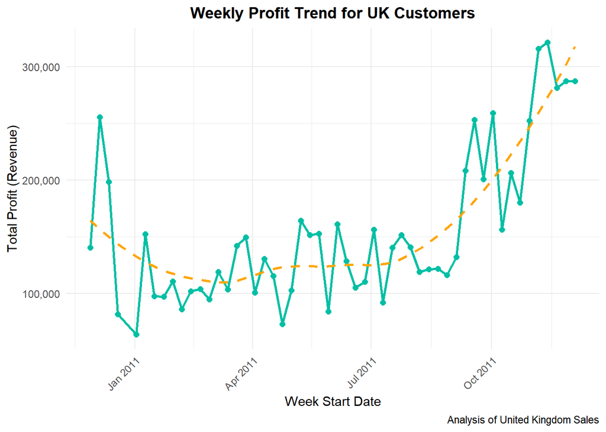

```r
# Filter the data to only include UK customers + ensure 'date_only' is a Date type.
uk_sales <- df_clean3_with_revenue %>%
  filter(Country == "United Kingdom") %>%
  # Note:'Revenue' column is accounting for returns.

  mutate(date_only = as.Date(date_only)) # Ensure date_only is in Date format for time series functions

# Function to aggregate and plot time-series data
plot_uk_sales <- function(data, period_function, period_label, plot_title) {

  # Aggregate data by time period (week, month, or quarter)
  aggregated_data <- data %>%
    mutate(Period = period_function(date_only)) %>% # Create the period column
    group_by(Period) %>%
    summarise(TotalProfit = sum(Revenue, na.rm = TRUE)) # Sum the revenue (profit)

  # 2. Create the line plot using ggplot()
  uk_line_plot <- ggplot(aggregated_data, aes(x = Period, y = TotalProfit)) +
    geom_line(color = "#00bfa5", linewidth = 1) + # Teal line for the trend
    geom_point(color = "#00bfa5", size = 2) + # Points at each period
    geom_smooth(method = "loess", se = FALSE, color = "#FFA500", linetype = "dashed") +
    # Adding orange smooth trend line, dashing for visibility.
    labs(
      title = plot_title,
      x = period_label,
      y = "Total Profit (Revenue)",
      caption = "Analysis of United Kingdom Sales"
    ) +
    scale_y_continuous(labels = scales::comma) + # Format y-axis for readability
    theme_minimal() + # Use a clean theme
    theme(
      plot.title = element_text(hjust = 0.5, face = "bold"),
      axis.text.x = element_text(angle = 45, hjust = 1) # Rotate X-axis labels for readability
    )

  print(uk_line_plot) # Display the plot
}

# --- Plotting Weekly Trends ---
# Note: For weekly trends, we use 'floor_date' to group dates into the start of the week.
plot_uk_sales(
  data = uk_sales,
  period_function = function(x) floor_date(x, unit = "week"),
  period_label = "Week Start Date",
  plot_title = "Weekly Profit Trend for UK Customers"
)
```

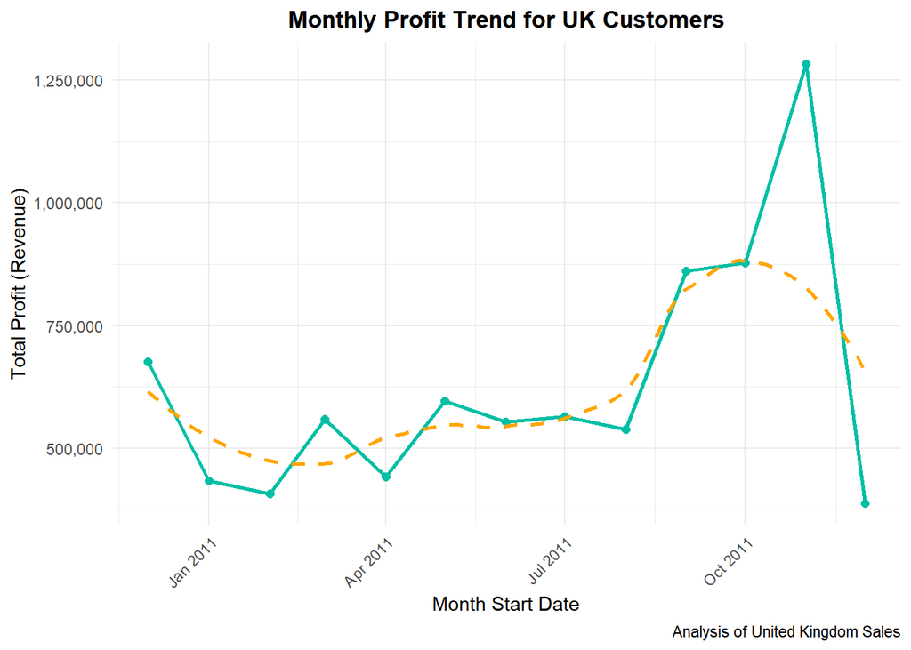

```r
# --- Plotting Monthly Trends ---
# Note: For monthly trends, we use 'floor_date' to group dates into the start of the month.
plot_uk_sales(
  data = uk_sales,
  period_function = function(x) floor_date(x, unit = "month"),
  period_label = "Month Start Date",
  plot_title = "Monthly Profit Trend for UK Customers"
)
```

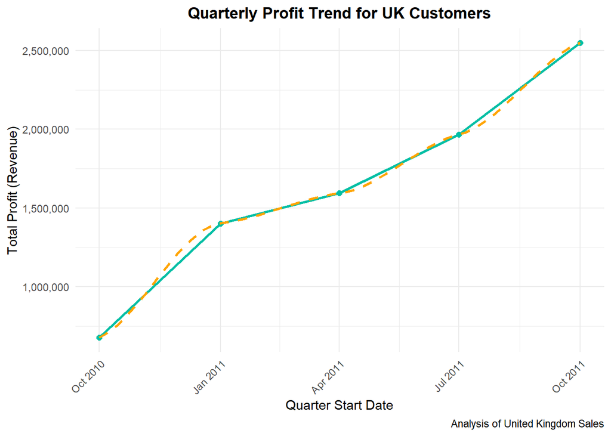

```r
# --- Plotting Quarterly Trends ---
# Note: For quarterly trends, we use 'floor_date' to group dates into the start of the quarter.
plot_uk_sales(
  data = uk_sales,
  period_function = function(x) floor_date(x, unit = "quarter"),
  period_label = "Quarter Start Date",
  plot_title = "Quarterly Profit Trend for UK Customers"
)
```

#### 2. Top ten products by revenue

```r
# 6.1: Top 10 Products by Revenue (Focusing on the "What")
# Assuming 'Description' is the product name column
top_products <- df_clean3_with_revenue %>%
  filter(Revenue > 0) %>% # Only count actual sales
  group_by(Description) %>%
  summarise(TotalRevenue = sum(Revenue, na.rm = TRUE)) %>%
  arrange(desc(TotalRevenue)) %>%
  head(10) # Select the top 10 products

# Create a bar chart for the top 10 products
p_top_products <- ggplot(top_products, aes(x = reorder(Description, TotalRevenue), y = TotalRevenue)) +
  geom_col(fill = "#00bfa5") + # Teal color for revenue
  coord_flip() + # Flip coordinates to make product names readable
  labs(
    title = "Top 10 Products by Total Revenue",
    x = "Product Description",
    y = "Total Revenue",
    caption = "Identifies key revenue drivers"
  ) +
  scale_y_continuous(labels = scales::comma) + # Format y-axis for readability
  theme_minimal() +
  theme(plot.title = element_text(hjust = 0.5, face = "bold"))

print("--- Top 10 Products by Revenue Plot: ---")
```

```
## [1] "--- Top 10 Products by Revenue Plot: ---"
```

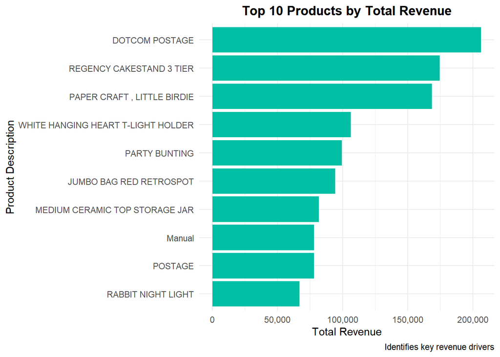

```r
print(p_top_products)
```

#### 3. Which days do we make the most sales?

```r
sales_by_day <- df_clean3_with_revenue %>%
  # Ensure we only look at successful sales
  filter(Revenue > 0) %>%
  # Use wday() to extract the day of the week, label=TRUE to get names, and abbr=FALSE for full names
  mutate(DayOfWeek = wday(date_only, label = TRUE, abbr = FALSE)) %>%
  group_by(DayOfWeek) %>%
  summarise(TotalRevenue = sum(Revenue, na.rm = TRUE))

# Create a bar chart for sales by day of the week
p_sales_by_day <- ggplot(sales_by_day, aes(x = DayOfWeek, y = TotalRevenue)) +
  geom_col(fill = "#00bfa5") + # Teal color
  labs(
    title = "Total Revenue by Day of the Week",
    x = "Day of Week",
    y = "Total Revenue",
    caption = "Identifies peak sales days for staffing/marketing/etc"
  ) +
  scale_y_continuous(labels = scales::comma) + # Format y-axis for readability
  theme_minimal() +
  theme(plot.title = element_text(hjust = 0.5, face = "bold"))

print("--- Revenue by Day of the Week Plot: ---")
```

```
## [1] "--- Revenue by Day of the Week Plot: ---"
```

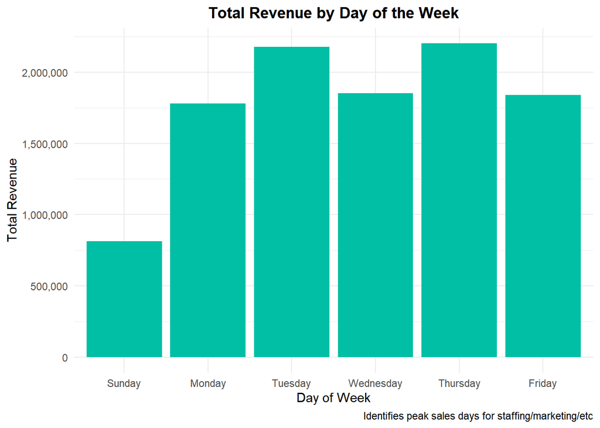

```r
print(p_sales_by_day)
```